# notebook89321c2557 (10)

```python
##import warnings
##warnings.filterwarnings('ignore')

import tensorflow as tf
from pathlib import Path
import numpy as np
import pandas as pd
import pandas_datareader.data as web
from sklearn.datasets import make_classification
from sklearn.preprocessing import MinMaxScaler
from imblearn.over_sampling import SMOTE
from sklearn.ensemble import IsolationForest
from sklearn.metrics import mean_absolute_error, roc_curve, auc
from tensorflow.keras.callbacks import ModelCheckpoint, EarlyStopping, ReduceLROnPlateau
from tensorflow.keras.models import Sequential, Model
from tensorflow.keras.layers import Dense, LSTM, GRU, SimpleRNN, Lambda
from imblearn.ensemble import BalancedRandomForestClassifier
import tensorflow.keras.backend as K
from tensorflow.keras.optimizers import RMSprop
from tensorflow.keras.models import load_model
from scipy.stats import chi2_contingency
from scipy.stats import f_oneway
import scipy.stats as stats
import statsmodels.api as sm
from statsmodels.formula.api import ols
import shap
from statsmodels.graphics.regressionplots import plot_partregress_grid
from scipy.stats import f_oneway, levene, shapiro
from sklearn.preprocessing import StandardScaler
from sklearn.decomposition import PCA
from sklearn.model_selection import train_test_split, cross_val_score
from sklearn.neural_network import MLPClassifier
from sklearn.ensemble import RandomForestClassifier, GradientBoostingClassifier
from sklearn.svm import SVC
from sklearn.linear_model import LogisticRegression
from sklearn.metrics import classification_report, confusion_matrix, roc_auc_score, accuracy_score, average_precision_score
from sklearn.model_selection import train_test_split
from sklearn.model_selection import RandomizedSearchCV, GridSearchCV
from xgboost import XGBClassifier
import glob
import os
import matplotlib.pyplot as plt
import time
from sklearn.metrics import classification_report, confusion_matrix
import itertools
import seaborn as sns
```

**1. Preprocessament i transformació de les dades**

```
Dimensions del dataset: (63326, 11)
Tipus de dades per columna:
Agency                   object
Agency Type              object
Distribution Channel     object
Product Name             object
Claim                    object
Duration                  int64
Destination              object
Net Sales               float64
Commision (in value)    float64
Gender                   object
Age                       int64
dtype: object
Mostra dels primers 5 registres:
  Agency    Agency Type Distribution Channel                     Product Name  \
0    CBH  Travel Agency              Offline               Comprehensive Plan
1    CBH  Travel Agency              Offline               Comprehensive Plan
2    CWT  Travel Agency               Online  Rental Vehicle Excess Insurance
3    CWT  Travel Agency               Online  Rental Vehicle Excess Insurance
4    CWT  Travel Agency               Online  Rental Vehicle Excess Insurance

  Claim  Duration Destination  Net Sales  Commision (in value) Gender  Age
0    No       186    MALAYSIA      -29.0                  9.57      F   81
1    No       186    MALAYSIA      -29.0                  9.57      F   71
2    No        65   AUSTRALIA      -49.5                 29.70    NaN   32
3    No        60   AUSTRALIA      -39.6                 23.76    NaN   32
4    No        79       ITALY      -19.8                 11.88    NaN   41
Estadístiques descriptives globals:
       Agency    Agency Type Distribution Channel       Product Name  Claim  \
count   63326          63326                63326              63326  63326
unique     16              2                    2                 26      2
top       EPX  Travel Agency               Online  Cancellation Plan     No
freq    35119          45869                62219              18630  62399
mean      NaN            NaN                  NaN                NaN    NaN
std       NaN            NaN                  NaN                NaN    NaN
min       NaN            NaN                  NaN                NaN    NaN
25%       NaN            NaN                  NaN                NaN    NaN
50%       NaN            NaN                  NaN                NaN    NaN
75%       NaN            NaN                  NaN                NaN    NaN
```

[output cut: 12 more lines]

```
75%        53.000000         NaN     48.000000             11.550000    NaN
max      4881.000000         NaN    810.000000            283.500000    NaN

                 Age
count   63326.000000
unique           NaN
top              NaN
freq             NaN
mean       39.969981
std        14.017010
min         0.000000
25%        35.000000
50%        36.000000
75%        43.000000
max       118.000000
```

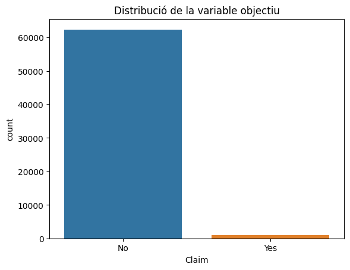

```
Percentatge de valors nuls per columna:
 Agency                   0.000000
Agency Type              0.000000
Distribution Channel     0.000000
Product Name             0.000000
Claim                    0.000000
Duration                 0.000000
Destination              0.000000
Net Sales                0.000000
Commision (in value)     0.000000
Gender                  71.229827
Age                      0.000000
dtype: float64
```

```python
# Carregar el fitxer
file_path = '/kaggle/input/insurance/insurance clean.csv'
data = pd.read_csv(file_path)

# Dimensions del dataset
print(f"Dimensions del dataset: {data.shape}")

# Tipus de dades
print("Tipus de dades per columna:")
print(data.dtypes)

# Mostra dels primers registres
print("Mostra dels primers 5 registres:")
print(data.head())

# Resum estadístic general
print("Estadístiques descriptives globals:")
print(data.describe(include='all'))

# Distribució variable "Claim"
sns.countplot(data=data, x='Claim')
plt.title("Distribució de la variable objectiu")
plt.show()

# Comprovem valors nuls
missing_summary = data.isnull().sum() / len(data) * 100
print("Percentatge de valors nuls per columna:\n", missing_summary)
```

Observem que pel camp "Gender", tenim més d'un 70% de valors nuls, i comprovarem ara si té una correlació o impacte sobre la variable objectiu "claim" per decidir si esborrar la columna o si fem un altre tipus de tractament.

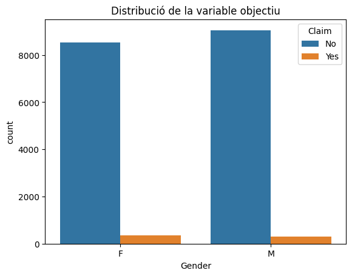

```python
sns.countplot(data=data, x='Gender', hue='Claim')
plt.title("Distribució de la variable objectiu")
plt.show()
```

Observem que no té una correlació forta amb la variable, ja que els resultats són molt similars entre els dos gèneres. Així, crec que el millor és eliminar la columna per simplificar l'anàlisi.

[output not shown]

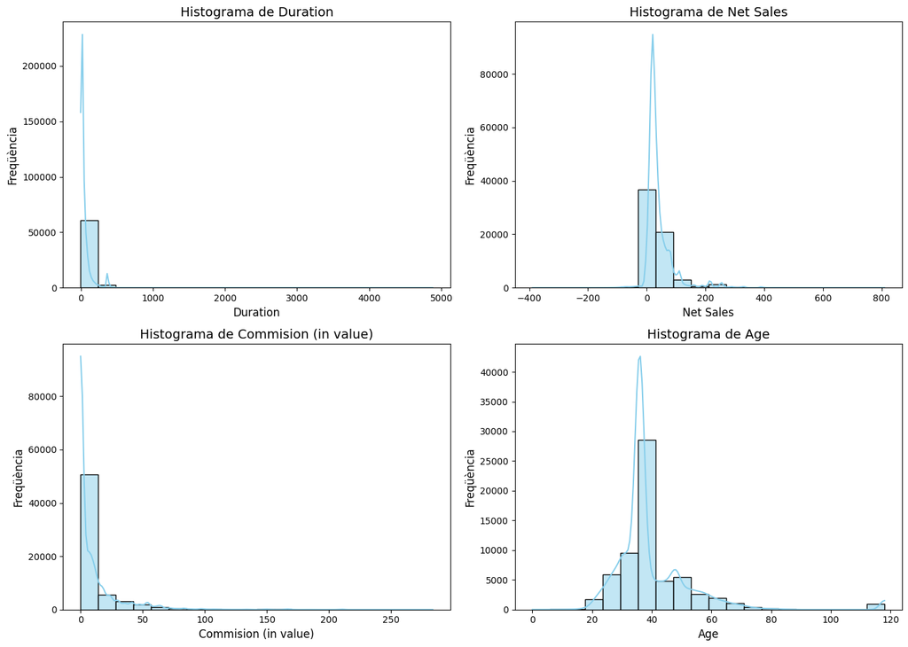

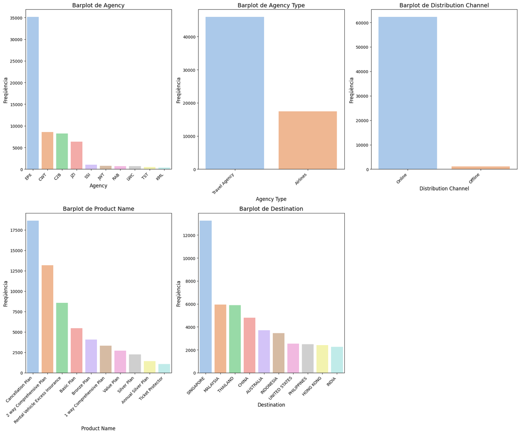

```
Resum de 'Duration':
 count    63326.000000
mean        49.317074
std        101.791566
min         -2.000000
25%          9.000000
50%         22.000000
75%         53.000000
max       4881.000000
Name: Duration, dtype: float64

Resum de 'Net Sales':
 count    63326.000000
mean        40.702018
std         48.845637
min       -389.000000
25%         18.000000
50%         26.530000
75%         48.000000
max        810.000000
Name: Net Sales, dtype: float64

Resum de 'Age':
 count    63326.000000
mean        39.969981
std         14.017010
min          0.000000
25%         35.000000
50%         36.000000
75%         43.000000
max        118.000000
Name: Age, dtype: float64

Resum de 'Commision':
 count    63326.000000
mean         9.809992
std         19.804388
min          0.000000
25%          0.000000
50%          0.000000
75%         11.550000
max        283.500000
Name: Commision (in value), dtype: float64
```

```python
# Eliminem la columna "Gender"
clean_data = data.drop(columns=['Gender'])

# Variables numèriques
numerical_columns = data.select_dtypes(include=['float64', 'int64']).columns

# Variables categòriques
no_claim_data = clean_data.drop(columns=['Claim'])
categorical_columns = no_claim_data.select_dtypes(include=['object', 'category']).columns

fig_hist, axes_hist = plt.subplots(2, 2, figsize=(14, 10))

for i, col in enumerate(numerical_columns):
    # Determinar la posició dels subgràfics
    row = i // 2  # Indica la fila (0 o 1)
    col_idx = i % 2  # Indica la columna (0 o 1)

    # Crear el histograma a la posició corresponent
    sns.histplot(data[col], bins=20, kde=True, ax=axes_hist[row, col_idx], color='skyblue')
    # Afegir títol i etiquetes
    axes_hist[row, col_idx].set_title(f'Histograma de {col}', fontsize=14)
    axes_hist[row, col_idx].set_xlabel(col, fontsize=12)
    axes_hist[row, col_idx].set_ylabel('Freqüència', fontsize=12)

# Ajustar l'espai entre els subgràfics per a la figura dels histogrames
plt.tight_layout()
# Mostrar la figura dels histogrames
plt.show()

# Ajustar l'espai entre els subgràfics per a la figura dels histogrames
plt.tight_layout()
# Mostrar la figura dels histogrames
plt.show()

fig_bar, axes_bar = plt.subplots(2, 3, figsize=(18, 15))

# Iterar sobre les columnes categòriques i crear els barplots
for i, col in enumerate(categorical_columns):
    # Determinar la posició dels subgràfics
    row = i // 3  # Indica la fila (0, 1 o 2)
    col_idx = i % 3  # Indica la columna (0, 1 o 2)

    # Obtenir les categories més freqüents
    top_categories = data[col].value_counts().nlargest(10).index
    # Crear el barplot a la posició corresponent
    sns.countplot(x=col, data=data, palette='pastel', order=top_categories, ax=axes_bar[row, col_idx])
    # Afegir títol i etiquetes
    axes_bar[row, col_idx].set_title(f'Barplot de {col}', fontsize=14)
    axes_bar[row, col_idx].set_xlabel(col, fontsize=12)
    axes_bar[row, col_idx].set_ylabel('Freqüència', fontsize=12)
    # Rotar les etiquetes de l'eix X per a millor llegibilitat
    axes_bar[row, col_idx].set_xticklabels(axes_bar[row, col_idx].get_xticklabels(), rotation=45, ha='right')

axes_bar[1, 2].axis('off')
plt.tight_layout()
plt.show()

# Detecció de valors extrems als camps numèrics
duration_summary = clean_data['Duration'].describe()
net_sales_summary = clean_data['Net Sales'].describe()
age_summary = clean_data['Age'].describe()
comission_summary = clean_data['Commision (in value)'].describe()

print("\nResum de 'Duration':\n", duration_summary)
print("\nResum de 'Net Sales':\n", net_sales_summary)
print("\nResum de 'Age':\n", age_summary)
print("\nResum de 'Commision':\n", comission_summary)
```

Observem que apareixen alguns valors negatius pels camps 'Duration' i 'Net Sales'. Estudiarem si només s'han de passar a positiu, o si pel contrari s'ha de fer un altre tractament:

```python
negative_duration = clean_data[(clean_data['Duration'] < 0)]
high_duration = clean_data[(clean_data['Duration'] > 1000)]
negative_sales = clean_data[(clean_data['Net Sales'] < 0)]
print("\n",negative_duration)
print("\nFiles amb Duration negatiu:\t", sum(n < 0 for n in clean_data['Duration']))
print("\n",high_duration)
print("\nFiles amb Duration superior a 1000 dies:\t", sum(n > 1000 for n in clean_data['Duration']))
print("\n",negative_sales)
print("\nFiles amb Net Sales negatiu:\t", sum(n < 0 for n in clean_data['Net Sales']))

clean_data = clean_data[(clean_data['Duration'] >= 0) & (clean_data['Duration'] <= 1000)]
clean_data['Net Sales'] = clean_data['Net Sales'].abs()
```

```
       Agency Agency Type Distribution Channel Product Name Claim  Duration  \
46600    JZI    Airlines               Online   Basic Plan    No        -2
57152    JZI    Airlines               Online   Basic Plan    No        -1
57153    JZI    Airlines               Online   Basic Plan    No        -1
58515    JZI    Airlines               Online   Basic Plan    No        -1
59432    JZI    Airlines               Online   Basic Plan    No        -1

             Destination  Net Sales  Commision (in value)  Age
46600         BANGLADESH       22.0                   7.7  118
57152           MALAYSIA       18.0                   6.3  118
57153  BRUNEI DARUSSALAM       18.0                   6.3  118
58515          INDONESIA       18.0                   6.3  118
59432              CHINA       22.0                   7.7  118

Files amb Duration negatiu:	 5
```

[output cut: 77 more lines]

Pel camp 'Net Sales', observem en la seva relació amb 'Comission' que té sentit simplement passar-los a positiu. Pel camp 'Duration', no veig una raó clara pels registres en negatiu, i al ser només 5 registres considero correcte eliminar-los del dataset.

Pels outliers, primer estudiarem la relació de cada camp numèric amb la variable objectiu 'Claim'. Per la variable 'Age' utilitzaré boxplots i IQR ja que considero que és univariada. Per a les variables 'Duration' i 'Net Sales' faré servir Isolation Forest ja que sospito que podrien tenir relacions més complexes amb la variable objectiu.

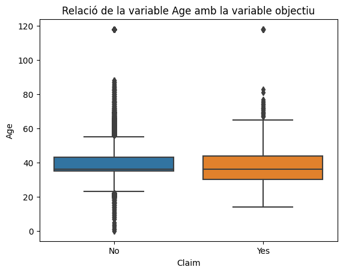

```
Relació de la variable Age amb la variable objectiu després de la neteja
```

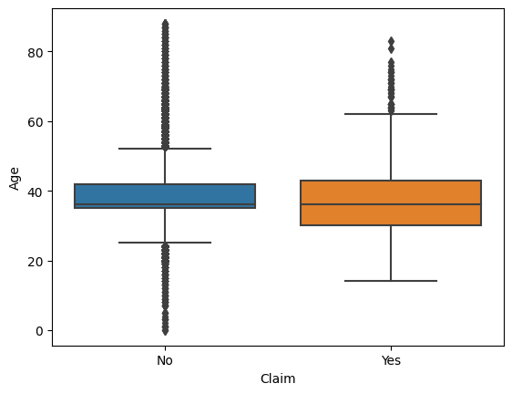

```
X does not have valid feature names, but IsolationForest was fitted with feature names
```

```
Nombre de files: 62673
```

```python
sns.boxplot(data=clean_data, x='Claim', y='Age')
plt.title("Relació de la variable Age amb la variable objectiu")
plt.show()

default_values = [118]
median = clean_data.loc[~clean_data['Age'].isin(default_values), 'Age'].median()
clean_data['Age'] = clean_data['Age'].apply(lambda x: median if x in default_values else x)

print("\nRelació de la variable Age amb la variable objectiu després de la neteja")
sns.boxplot(data=clean_data, x='Claim', y='Age')
plt.show()

iso_forest = IsolationForest(contamination=0.01, random_state=42)
clean_data['outlier'] = iso_forest.fit_predict(clean_data[['Duration', 'Net Sales', 'Commision (in value)']])
clean_data = clean_data[clean_data['outlier'] == 1].drop(columns=['outlier'])
print("\nNombre de files:", clean_data.shape[0])
```

S'han observat valors molt elevats en la edat, concretament una quantitat considerable de registres amb el valor '118'. Considero que aquest valor es va posar com a valor per defecte en els casos que no es sabia la edat, així que el reemplaçaré per la mediana ja que el camp presenta una distribució força normal.

A més de l'estudi de les variables numèriques i categòriques per separat, és interessant dur a terme també un anàlisi de variància (ANOVA), una tècnica estadística que ens permet determinar si existeixen diferències estadísticament significatives entre les mitjanes de diferents grups. En el context de l'anàlisi de dades, es pot utilitzar per investigar si una variable categòrica influeix en les mitjanes d'una variable numèrica.

En aquest cas d'estudi, treballant amb un dataset desbalancejat per predir una variable objectiu binària, i variables explicatives tant numèriques com categòriques, l'objectiu serà utilitzar l'ANOVA per determinar si les variables numèriques tenen diferències estadísticament significatives entre les categories de la variable objectiu.

L'anàlisi ANOVA només es dona resultats fiables si les diferents variables presenten normalitat i homogeneïtat. En el cas del dataset d'estudi, s'ha trobat que no presenten aquestes característiques, així que s'ha decantat per un test no paramètric com és el Kruskal-Wallis, ja que no requereix que les dades segueixin una distribució normal ni que tinguin variàncies homogènies.

```python
transformed_data = clean_data.copy()
from scipy.stats import kruskal


for var in numerical_columns:
    group1 = transformed_data[transformed_data['Claim'] == 'Yes'][var]
    group2 = transformed_data[transformed_data['Claim'] == 'No'][var]
    # Test de normalitat
    _, p_normal1 = shapiro(group1)
    _, p_normal2 = shapiro(group2)
    print(f"\nNormalitat per {var}: Grup 1 (p={p_normal1}), Grup 2 (p={p_normal2})")
    # Test de homogeneïtat de variàncies
    _, p_levene = levene(group1, group2)
    print(f"Homogeneïtat de variàncies per {var} (p={p_levene})")

print("Resultats del test Kruskal-Wallis per les variables numèriques: Net Sales, Comission, Duration i Age")
for var in numerical_columns:
    group1 = transformed_data[transformed_data['Claim'] == 'Yes'][var]
    group2 = transformed_data[transformed_data['Claim'] == 'No'][var]
    # Test Kruskal-Wallis
    stat, p_value = kruskal(group1, group2)
    print(f"Kruskal-Wallis Test: Statistic = {stat}, p-value = {p_value}")
```

```
Normalitat per Duration: Grup 1 (p=5.694940633222115e-39), Grup 2 (p=9.838497015058403e-141)
Homogeneïtat de variàncies per Duration (p=1.2397569523608375e-94)

Normalitat per Net Sales: Grup 1 (p=7.531789968974125e-33), Grup 2 (p=9.956696140403985e-131)
Homogeneïtat de variàncies per Net Sales (p=2.7567637158136367e-134)

Normalitat per Commision (in value): Grup 1 (p=3.0223985064175857e-30), Grup 2 (p=1.2042780450257747e-139)
Homogeneïtat de variàncies per Commision (in value) (p=7.36847420379151e-52)

Normalitat per Age: Grup 1 (p=2.754267765172084e-22), Grup 2 (p=2.250009982278703e-108)
Homogeneïtat de variàncies per Age (p=8.764430069409376e-11)
Resultats del test Kruskal-Wallis per les variables numèriques: Net Sales, Comission, Duration i Age
Kruskal-Wallis Test: Statistic = 122.26306896295009, p-value = 2.0217248530236907e-28
Kruskal-Wallis Test: Statistic = 421.7766580150292, p-value = 1.001699735936732e-93
Kruskal-Wallis Test: Statistic = 469.5469869162342, p-value = 4.021126889023514e-104
Kruskal-Wallis Test: Statistic = 32.126717027506054, p-value = 1.4443730718929466e-08
```

```
scipy.stats.shapiro: For N > 5000, computed p-value may not be accurate. Current N is 61806.
```

Dels resultats del test de Kruskal es treu que tots els resultats indiquen que rebutgem la hipòtesi nul·la (que afirma que les distribucions entre els grups són iguals). Això implica que hi ha diferències significatives en les distribucions de les variables entre els grups en cada un dels casos.

Com a pas previ a entrenar els models, és important que es faci un tractament de totes les variables categòriques, i transformar-les a un format numèric. Per a les que tenen valors binaris (Agency Type, Distribution Channel, Claim) es modificaràn aquests valors al rang (0,1), i s'ha fet servir frequency encoding per les variables amb més valors únics. S'ha decidit per aquesta opció perque aquest tipus de encoding no depèn de la variable objectiu i per tant no hi ha el risc d'overfitting per les categories amb una classe objectiu amb freqüència 0, com és el cas d'algunes de les nostres variables.

```python
clean_data['Agency Type'] = clean_data['Agency Type'].map({'Travel Agency': 1, 'Airlines': 0})
clean_data['Distribution Channel'] = clean_data['Distribution Channel'].map({'Online': 1, 'Offline': 0})
clean_data['Claim'] = clean_data['Claim'].map({'No': 0, 'Yes': 1})
# Funció per aplicar Frequency Encoding a múltiples columnes
def frequency_encoding(clean_data, columns):
    for col in columns:
        freq_map = clean_data[col].value_counts().to_dict()
        clean_data[col] = clean_data[col].map(freq_map)
    return clean_data

columns_to_encode = ['Agency', 'Product Name', 'Destination']
clean_data = frequency_encoding(clean_data, columns_to_encode)

print(clean_data)


# Separem les característiques i la variable objectiu
X = clean_data.drop('Claim', axis=1)
y = clean_data['Claim']

# Divisió del dataset en entrenament i test
X_train, X_test, y_train, y_test = train_test_split(X, y, test_size=0.3, random_state=42, stratify=y)

# Normalitzem les característiques
scaler = StandardScaler()
X_train_scaled = scaler.fit_transform(X_train)
X_test_scaled = scaler.transform(X_test)
X_train_scaled_df = pd.DataFrame(X_train_scaled, columns=X_train.columns)
X_test_scaled_df = pd.DataFrame(X_test_scaled, columns=X_test.columns)
print(X_train_scaled_df)
print(X_test_scaled_df)
```

```
       Agency  Agency Type  Distribution Channel  Product Name  Claim  \
0         101            1                     0           364      0
1         101            1                     0           364      0
2        8537            1                     1          8537      0
3        8537            1                     1          8537      0
4        8537            1                     1          8537      0
...       ...          ...                   ...           ...    ...
63321   35119            1                     1         13158      0
63322   35119            1                     1         18630      0
63323    8537            1                     1          8537      0
63324   35119            1                     1         18630      0
63325   35119            1                     1         18630      0

       Duration  Destination  Net Sales  Commision (in value)   Age
0           186         5929       29.0                  9.57  81.0
```

[output cut: 66 more lines]

**2. Tècniques d'equilibrat de classes i tractament EDA**

Seguidament durem a terme l'anàlisi exploratòria de dades (EDA), que inclourà:

- Anàlisi de correlació i gràfics de correlacions parcials.
- Reducció de dimensionalitat amb PCA.
- Anàlisi d'interacció entre variables.

Al tenir la variable "claim" altament desequilibrada, farem servir SMOTE com a tènica d'equilibrament de classes. Considero que és millor opció que fer undersampling o oversampling al estar tant desequilibrades, ja que resultarien en un dataset massa petit o es generaria molt de overffiting. També la considero millor opció que Class Weighting, o tècniques com bagging i boosting per la presencia d'un desequilibri molt accentuat i la seva relativa facilitat de implementació i baixos costos computacionals respecte algunes de les alternatives.

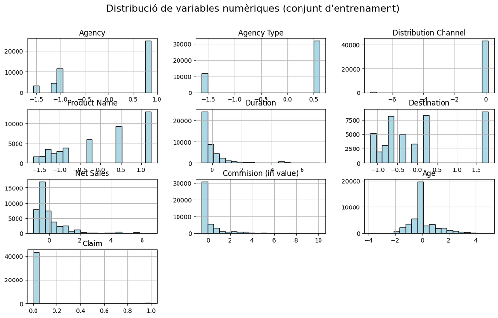

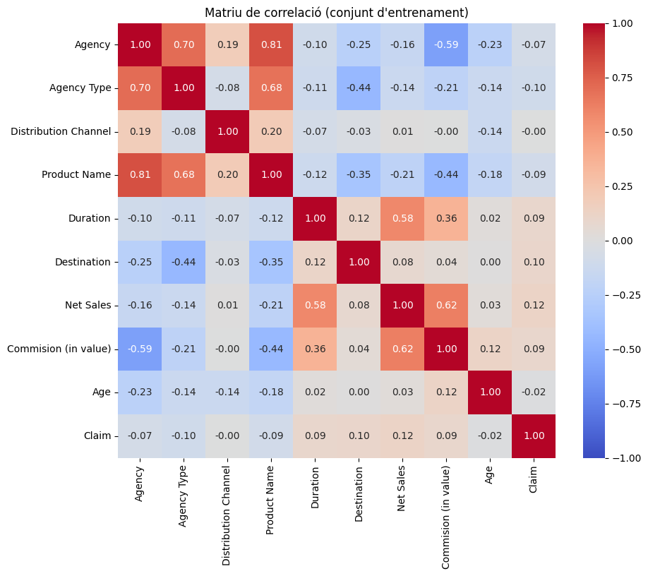

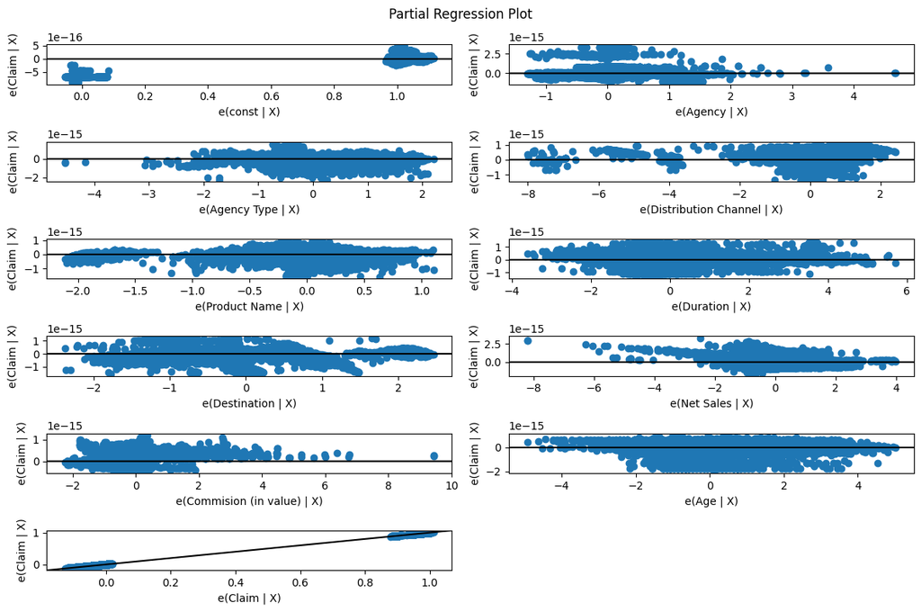

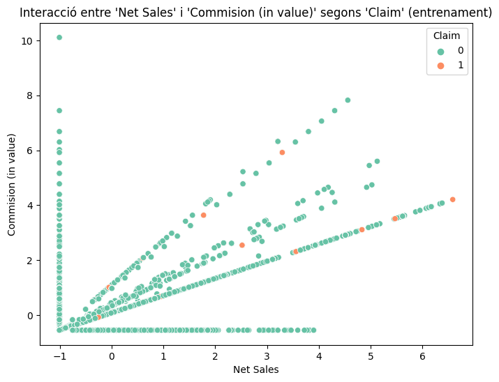

```
Distribució de la variable objectiu després de SMOTE al conjunt d'entrenament:
Claim
0    43264
1    43264
Name: count, dtype: int64
Conjunt d'entrenament (característiques): (86528, 7)
Conjunt de test (característiques): (18802, 7)

PCA: Variància explicada per component principal: [0.44058896 0.20323351]
```

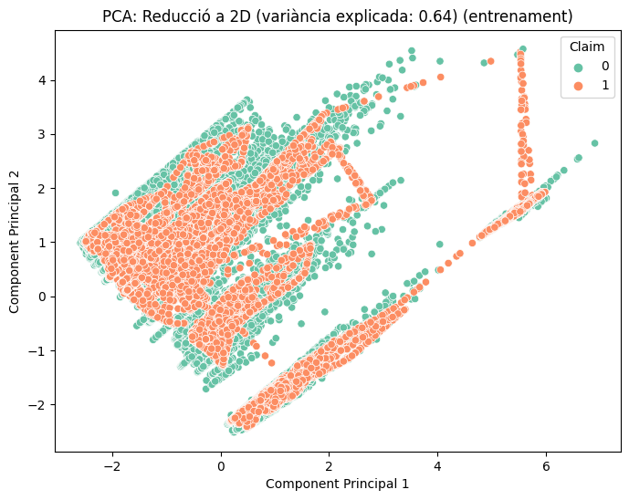

```
Càrregues de les variables originals (entrenament):
     Agency Type  Distribution Channel  Product Name  Duration  Destination  \
PC1    -0.366274              0.006810     -0.335649  0.621714     0.360012
PC2     0.508446             -0.041923      0.321693  0.531531    -0.510980

     Commision (in value)       Age
PC1              0.485355  0.037821
PC2              0.301964  0.037841
```

```python
# --- Anàlisi preliminar ---

train_data = pd.DataFrame(X_train_scaled, columns=X.columns)
train_data['Claim'] = y_train.values
# Distribució de variables numèriques
num_vars = train_data.select_dtypes(include=['float64', 'int64']).columns
train_data[num_vars].hist(figsize=(14, 8), bins=20, color='lightblue', edgecolor='black')
plt.suptitle("Distribució de variables numèriques (conjunt d'entrenament)", fontsize=16)
plt.show()

# --- Anàlisi de correlació ---
# Matriu de correlació de variables numèriques
corr_matrix = train_data[num_vars].corr()

# Visualització: Mapa de calor
plt.figure(figsize=(10, 8))
sns.heatmap(corr_matrix, annot=True, fmt='.2f', cmap='coolwarm', vmin=-1, vmax=1)
plt.title("Matriu de correlació (conjunt d'entrenament)")
plt.show()

# Correlació parcial utilitzant la variable objectiu
partial_model = sm.OLS(train_data['Claim'], sm.add_constant(train_data[num_vars].fillna(0))).fit()
fig = plt.figure(figsize=(12, 8))
plot_partregress_grid(partial_model, fig=fig)
plt.tight_layout()
plt.show()


# --- Anàlisi d'interacció entre variables ---

# Scatter plot entre "Net Sales" i "Commision (in value)" segons "Claim" (conjunt d'entrenament)
plt.figure(figsize=(8, 6))
sns.scatterplot(data=train_data, x="Net Sales", y="Commision (in value)", hue="Claim", palette="Set2")
plt.title("Interacció entre 'Net Sales' i 'Commision (in value)' segons 'Claim' (entrenament)")
plt.show()

# Eliminem les variables "Agency" i "Net Sales" del conjunt d'entrenament i test
X_train = pd.DataFrame(X_train_scaled, columns=X.columns).drop(columns=['Net Sales', 'Agency'])
X_test = pd.DataFrame(X_test_scaled, columns=X.columns).drop(columns=['Net Sales', 'Agency'])

# Apliquem SMOTE per equilibrar les classes
smote = SMOTE(random_state=42)
X_train_resampled, y_train_resampled = smote.fit_resample(X_train, y_train)

# Mostrar un resum del dataset entrenament després de SMOTE
print("Distribució de la variable objectiu després de SMOTE al conjunt d'entrenament:")
print(pd.Series(y_train_resampled).value_counts())

# Conjunts finals
print("Conjunt d'entrenament (característiques):", X_train_resampled.shape)
print("Conjunt de test (característiques):", X_test.shape)

# --- 4. Reducció de dimensionalitat amb PCA ---

X_vars = train_data[num_vars].columns

# Aplicació PCA
pca = PCA(n_components=2)
X_train_pca = pca.fit_transform(X_train_resampled)
X_test_pca = pca.transform(X_test)
pca_variance = pca.explained_variance_ratio_
print("\nPCA: Variància explicada per component principal:", pca_variance)

# Visualització de PCA
plt.figure(figsize=(8, 6))
sns.scatterplot(x=X_train_pca[:, 0], y=X_train_pca[:, 1], hue=y_train_resampled, palette='Set2')
plt.title(f"PCA: Reducció a 2D (variància explicada: {sum(pca_variance):.2f}) (entrenament)")
plt.xlabel("Component Principal 1")
plt.ylabel("Component Principal 2")
plt.legend(title='Claim', loc='best')
plt.show()

components_df = pd.DataFrame(pca.components_,
	                             columns=X_train.columns,
	                             index=['PC1', 'PC2'])
print("Càrregues de les variables originals (entrenament):")
print(components_df)
```

D'aquest anàlisi podem treure algunes conclusions inicials a nivell de variables. Per a la matriu de correlació, veiem que tenim alguns camps que podrien ser redundants. El camp "Agency" té una forta correlació amb "Agency Type" i "Product Name", i crec que té sentit eliminar-lo de l'estudi ja que la informació que aporta es solapa amb aquests dos camps. De manera similar, la variable "Net Sales" té una forta correlació amb "Comission" i "Duration". Per a aquesta variable crec que el millor seria també eliminar-la perque es solapa molta informació especialment amb "Comission".

**4. Desenvolupament del model predictiu**

Per a la elecció de models, s'estudiaran:

**Àrbres de decisió i ensembles (Random Forests, Gradient Boosting)**

Aquests models són adequats per dades mixtes (numèriques i categòriques), i gestionen bé interaccions complexes i relacions no lineals entre variables. A més, són robustos davant dades desequilibrades quan es combina amb tècniques com class_weight o SMOTE, i poden gestionar pesos baixos de variables sense necessitat d'eliminació explícita. En el cas específic, es farà servir la variació Balanced Random Forest degut al fort desequilibri de classes.

**Xarxes neuronals artificials (ANNs)**

Són adequades per capturar relacions complexes que poden no ser evidents mitjançant altres models. Utilitzar PCA en aquest cas pot ser útil per reduir la dimensionalitat i eliminar soroll abans d'entrenar la xarxa neuronal, i funciona millor amb dades equilibrades con les del nostre dataset després d'aplicar SMOTE.

**Suport Vector Machines (SVM)**

Aquest tipus de models són potents per a classificació binària i per casos amb poques dimensions. Afegint un kernel no lineal es poden fer servir per estudiar patrons més complexes.

**Regressió logística**

No estudiarem el rendiment de models com **KNN**, ja que utilitzant SMOTE es creen nous exemples interpolant punts existents, cosa que pot causar redundància o soroll en els punts propers. Això pot confondre el KNN, ja que depèn de les distàncies euclidianes (o altres mètriques similars) per classificar.

Per a tots els models, buscarem els hiperparàmetres ideals provant diferents combinacions i quedant-nos amb els millors resultats, i farem servir tècniques de **validació creuada** per a garantir un rendiment sòlid del model després d'afegir dades sintètiques per SMOTE.

**Random Forest**

```
Fitting 5 folds for each of 10 candidates, totalling 50 fits
Millors hiperparàmetres per Random Forest: {'n_estimators': 200, 'min_samples_split': 5, 'min_samples_leaf': 1, 'max_depth': 10, 'bootstrap': False}
Millor puntuació d'entrenament: 0.8341157702825889

Resultats Random Forest :
              precision    recall  f1-score   support

           0       0.99      0.84      0.91     18543
           1       0.05      0.64      0.10       264

    accuracy                           0.84     18807
   macro avg       0.52      0.74      0.50     18807
weighted avg       0.98      0.84      0.90     18807

Accuracy: 0.8353804434519062
Matriu de confusió:
[[15542  3001]
 [   95   169]]
ROC AUC Score: 0.8220
```

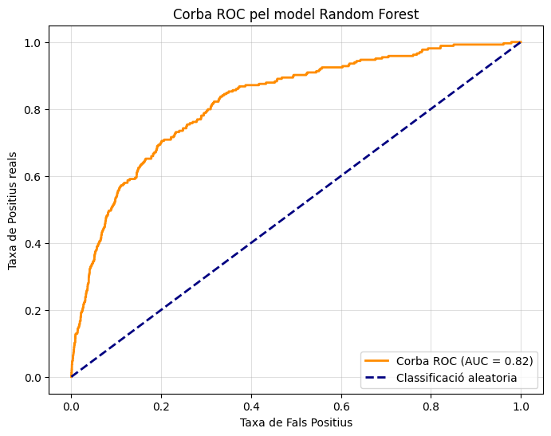

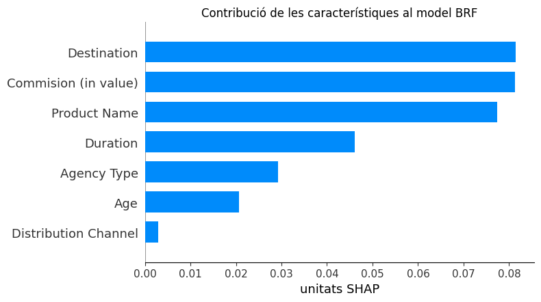

```python
# --------------------
# Model 1: Balanced Random Forest
# --------------------

rf = BalancedRandomForestClassifier(random_state=42, replacement=True, sampling_strategy='all')

# Definir el rang d'hiperparàmetres
rf_param_grid = {
    'n_estimators': [100, 200, 500],
    'max_depth': [None, 10, 20, 30],
    'min_samples_split': [2, 5, 10],
    'min_samples_leaf': [1, 2, 4],
    'bootstrap': [True, False]
}

# Configurar RandomizedSearchCV
rf_random_search = RandomizedSearchCV(
    estimator=rf,
    param_distributions=rf_param_grid,
    n_iter=10,
    cv=5,
    verbose=1,
    random_state=42,
    n_jobs= 1
)

# Entrenar el model
rf_random_search.fit(X_train, y_train)

# Resultats
print(f"Millors hiperparàmetres per Random Forest: {rf_random_search.best_params_}")
print(f"Millor puntuació d'entrenament: {rf_random_search.best_score_}")

# Avaluar Random Forest
rf_best = rf_random_search.best_estimator_
y_pred_rf = rf_best.predict(X_test)
print("\nResultats Random Forest :")
print(classification_report(y_test, y_pred_rf))
print(f"Accuracy: {accuracy_score(y_test, y_pred_rf)}")
print("Matriu de confusió:")
print(confusion_matrix(y_test, y_pred_rf))
y_pred_proba = rf_best.predict_proba(X_test)[:, 1]
roc_auc = roc_auc_score(y_test, y_pred_proba)
print(f"ROC AUC Score: {roc_auc:.4f}")

# --- Visualització Corba ROC ---
fpr, tpr, _ = roc_curve(y_test, y_pred_proba)
roc_auc = auc(fpr, tpr)

plt.figure(figsize=(8, 6))
plt.plot(fpr, tpr, color='darkorange', lw=2, label=f"Corba ROC (AUC = {roc_auc:.2f})")
plt.plot([0, 1], [0, 1], color='navy', lw=2, linestyle='--', label='Classificació aleatoria')
plt.xlabel("Taxa de Fals Positius")
plt.ylabel("Taxa de Positius reals")
plt.title("Corba ROC pel model Random Forest")
plt.legend(loc="lower right")
plt.grid(alpha=0.4)
plt.show()

explainer = shap.TreeExplainer(rf_best)

# Calculem valors SHAP
shap_values = explainer.shap_values(X_test)
fig, ax = plt.subplots()
shap.summary_plot(shap_values[1], X_test, show=False, plot_type="bar")
plt.title("Contribució de les característiques al model BRF")
plt.xlabel("unitats SHAP")
plt.show()
```

```
Fitting 5 folds for each of 10 candidates, totalling 50 fits

Millors hiperparàmetres per Gradient Boosting: {'subsample': 0.8, 'n_estimators': 200, 'max_depth': 10, 'learning_rate': 0.1, 'colsample_bytree': 1.0}

Millor puntuació d'entrenament: 0.9575660893345488

Resultats Gradient Boosting:
              precision    recall  f1-score   support

           0       0.99      0.96      0.98     18543
           1       0.06      0.17      0.09       264

    accuracy                           0.95     18807
   macro avg       0.53      0.57      0.53     18807
weighted avg       0.97      0.95      0.96     18807

Accuracy: 0.9533152549582602

Matriu de confusió:
[[17885   658]
 [  220    44]]

ROC AUC Score: 0.7519
```

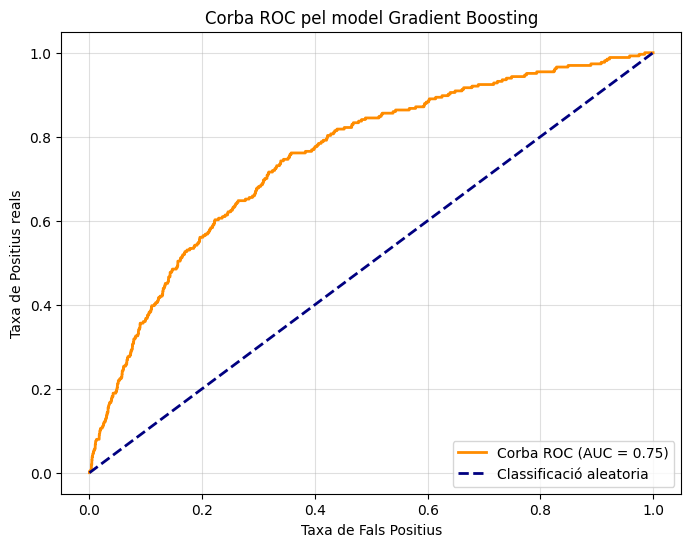

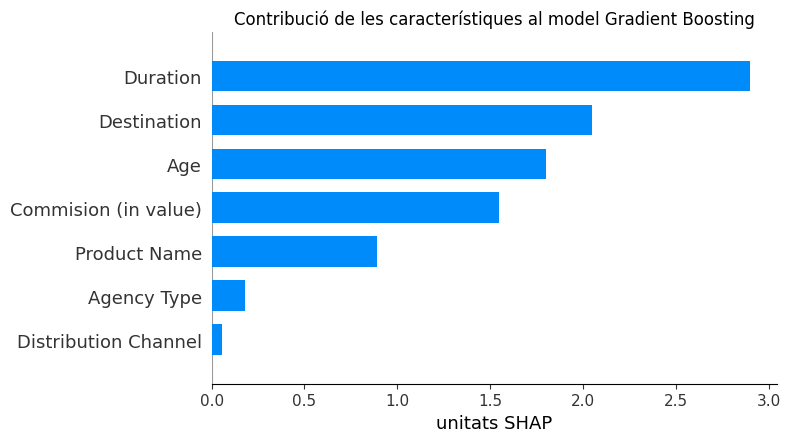

```python
# --------------------
# Model 2: Gradient Boosting
# --------------------

gb = XGBClassifier(random_state=42, scale_pos_weight=100)

# Definir el rang d'hiperparàmetres
gb_param_grid = {
    'n_estimators': [100, 200, 500],
    'learning_rate': [0.01, 0.05, 0.1],
    'max_depth': [3, 5, 10],
    'subsample': [0.6, 0.8, 1.0],
    'colsample_bytree': [0.6, 0.8, 1.0]
}

# Configurar RandomizedSearchCV
gb_random_search = RandomizedSearchCV(
    estimator=gb,
    param_distributions=gb_param_grid,
    n_iter=10,
    cv=5,
    verbose=1,
    random_state=42,
    n_jobs= 1
)
# Entrenar el model
gb_random_search.fit(X_train, y_train)

# Resultats
print(f"\nMillors hiperparàmetres per Gradient Boosting: {gb_random_search.best_params_}")
print(f"\nMillor puntuació d'entrenament: {gb_random_search.best_score_}")

# Avaluació Gradient Boosting
gb_best = gb_random_search.best_estimator_
y_pred_gb = gb_best.predict(X_test)
print("\nResultats Gradient Boosting:")
print(classification_report(y_test, y_pred_gb))
print(f"Accuracy: {accuracy_score(y_test, y_pred_gb)}")
print("\nMatriu de confusió:")
print(confusion_matrix(y_test, y_pred_gb))
y_pred_proba = gb_best.predict_proba(X_test)[:, 1]
roc_auc = roc_auc_score(y_test, y_pred_proba)
print(f"\nROC AUC Score: {roc_auc:.4f}")

# --- Visualització Corba ROC ---
fpr, tpr, _ = roc_curve(y_test, y_pred_proba)
roc_auc = auc(fpr, tpr)

plt.figure(figsize=(8, 6))
plt.plot(fpr, tpr, color='darkorange', lw=2, label=f"Corba ROC (AUC = {roc_auc:.2f})")
plt.plot([0, 1], [0, 1], color='navy', lw=2, linestyle='--', label='Classificació aleatoria')
plt.xlabel("Taxa de Fals Positius")
plt.ylabel("Taxa de Positius reals")
plt.title("Corba ROC pel model Gradient Boosting")
plt.legend(loc="lower right")
plt.grid(alpha=0.4)
plt.show()

explainer = shap.Explainer(gb_best)

# Calculem valors SHAP
shap_values = explainer(X_test)
shap.summary_plot(shap_values, X_test, show=False, plot_type="bar")
plt.title("Contribució de les característiques al model Gradient Boosting")
plt.xlabel("unitats SHAP")
plt.show()
```

```
The total space of parameters 30 is smaller than n_iter=200. Running 30 iterations. For exhaustive searches, use GridSearchCV.
```

```
Fitting 5 folds for each of 30 candidates, totalling 150 fits

Millors hiperparàmetres per Regressió Logística: {'solver': 'saga', 'max_iter': 100, 'C': 100}

Millor puntuació d'entrenament: 0.7576219444048483

Resultats Regressió Logística :
              precision    recall  f1-score   support

           0       0.99      0.76      0.86     18543
           1       0.04      0.69      0.07       264

    accuracy                           0.76     18807
   macro avg       0.52      0.72      0.47     18807
weighted avg       0.98      0.76      0.85     18807

Accuracy: 0.75663316850109

Matriu de confusió:
[[14049  4494]
 [   83   181]]

ROC AUC Score: 0.7698
```

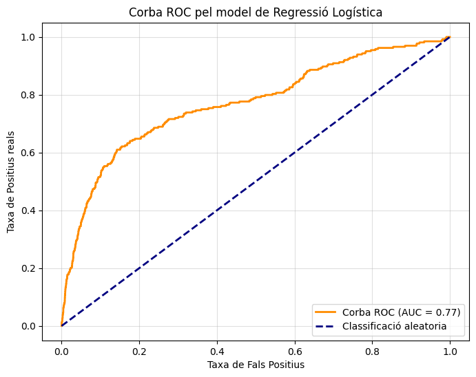

[figure not shown]

```python
# --------------------
# Model 3: Regressió Logística
# --------------------

log_reg_param_distributions = {
    'C': [0.01, 0.1, 1, 10, 100],
    'solver': ['saga', 'lbfgs'],
    'max_iter': [100, 300, 1000],
}

logistic_search = RandomizedSearchCV(
    LogisticRegression(random_state=42, class_weight='balanced'),
    param_distributions=log_reg_param_distributions,
    n_iter=200,
    cv=5,
    scoring='roc_auc',
    verbose=1,
    n_jobs=1,
    random_state=42,
)

logistic_search.fit(X_train_resampled, y_train_resampled)
print(f"\nMillors hiperparàmetres per Regressió Logística: {logistic_search.best_params_}")
print(f"\nMillor puntuació d'entrenament: {logistic_search.best_score_}")

# Avaluació Regressió Logística
log_best_model = logistic_search.best_estimator_
y_pred_log = log_best_model.predict(X_test)
print("\nResultats Regressió Logística :")
print(classification_report(y_test, y_pred_log))
print(f"Accuracy: {accuracy_score(y_test, y_pred_log)}")
print("\nMatriu de confusió:")
print(confusion_matrix(y_test, y_pred_log))
y_pred_proba = log_best_model.predict_proba(X_test)[:, 1]
roc_auc = roc_auc_score(y_test, y_pred_proba)
print(f"\nROC AUC Score: {roc_auc:.4f}")

# --- Visualització Corba ROC ---
fpr, tpr, _ = roc_curve(y_test, y_pred_proba)
roc_auc = auc(fpr, tpr)

plt.figure(figsize=(8, 6))
plt.plot(fpr, tpr, color='darkorange', lw=2, label=f"Corba ROC (AUC = {roc_auc:.2f})")
plt.plot([0, 1], [0, 1], color='navy', lw=2, linestyle='--', label='Classificació aleatoria')
plt.xlabel("Taxa de Fals Positius")
plt.ylabel("Taxa de Positius reals")
plt.title("Corba ROC pel model de Regressió Logística")
plt.legend(loc="lower right")
plt.grid(alpha=0.4)
plt.show()


explainer = shap.Explainer(log_best_model, X_train)
# Calculem valors SHAP
shap_values = explainer(X_test)
shap.summary_plot(shap_values, X_test, feature_names=X.columns, show=False, plot_type="bar")
plt.title("Contribució de les característiques al model de regressió logística")
plt.xlabel("unitats SHAP")
plt.show()
```

```
Fitting 5 folds for each of 5 candidates, totalling 25 fits

Millors hiperparàmetres per ANN: {'solver': 'adam', 'learning_rate': 'constant', 'hidden_layer_sizes': (50,), 'alpha': 0.0001, 'activation': 'tanh'}

Millor puntuació d'entrenament: 0.809153126863275

Resultats Gradient Boosting:
              precision    recall  f1-score   support

           0       0.99      0.81      0.89     18543
           1       0.05      0.64      0.08       264

    accuracy                           0.81     18807
   macro avg       0.52      0.72      0.49     18807
weighted avg       0.98      0.81      0.88     18807

Accuracy: 0.8074653054713671

Matriu de confusió:
[[15018  3525]
 [   96   168]]

ROC AUC Score: 0.7962
```

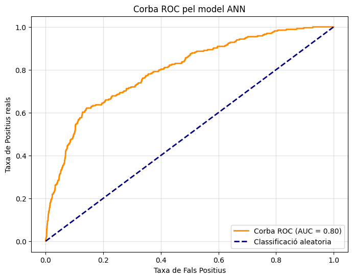

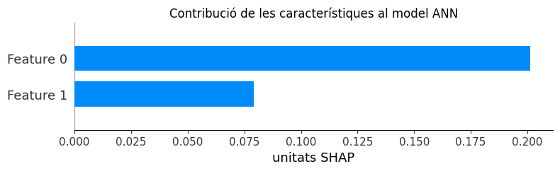

```python
# --------------------
# Model 4: Xarxes Neuronals Artificials
# --------------------

# Espai d'hiperparàmetres per ANN
ann_param_grid = {
    'hidden_layer_sizes': [(50,)],
    'activation': ['tanh', 'relu'],
    'solver': ['adam', 'sgd'],
    'alpha': [0.0001, 0.001, 0.01],
    'learning_rate': ['constant', 'adaptive']
}

ann_search = RandomizedSearchCV(MLPClassifier(max_iter=500, random_state=42),
                                 param_distributions=ann_param_grid,
                                 n_iter=5, cv=5, scoring='roc_auc', verbose=1, random_state=42, n_jobs=1)

ann_search.fit(X_train_pca, y_train_resampled)
print(f"\nMillors hiperparàmetres per ANN: {ann_search.best_params_}")
print(f"\nMillor puntuació d'entrenament: {ann_search.best_score_}")

# Avaluació ANN
ann_best_model = ann_search.best_estimator_
y_pred_ann = ann_best_model.predict(X_test_pca)
print("\nResultats Gradient Boosting:")
print(classification_report(y_test, y_pred_ann))
print(f"Accuracy: {accuracy_score(y_test, y_pred_ann)}")
print("\nMatriu de confusió:")
print(confusion_matrix(y_test, y_pred_ann))
y_pred_proba = ann_best_model.predict_proba(X_test_pca)[:, 1]
roc_auc = roc_auc_score(y_test, y_pred_proba)
print(f"\nROC AUC Score: {roc_auc:.4f}")

# --- Visualització Corba ROC ---
fpr, tpr, _ = roc_curve(y_test, y_pred_proba)
roc_auc = auc(fpr, tpr)

plt.figure(figsize=(8, 6))
plt.plot(fpr, tpr, color='darkorange', lw=2, label=f"Corba ROC (AUC = {roc_auc:.2f})")
plt.plot([0, 1], [0, 1], color='navy', lw=2, linestyle='--', label='Classificació aleatoria')
plt.xlabel("Taxa de Fals Positius")
plt.ylabel("Taxa de Positius reals")
plt.title("Corba ROC pel model ANN")
plt.legend(loc="lower right")
plt.grid(alpha=0.4)
plt.show()

explainer = shap.KernelExplainer(ann_best_model.predict_proba, shap.kmeans(X_train_pca, 10))

# Calculem valors SHAP
shap_values = explainer.shap_values(X_test_pca)
shap.summary_plot(shap_values[1], X_test_pca, show=False, plot_type="bar")
plt.title("Contribució de les característiques al model ANN")
plt.xlabel("unitats SHAP")
plt.show()
```

```
Fitting 2 folds for each of 5 candidates, totalling 10 fits
[CV] END .....................C=0.1, gamma=scale, kernel=rbf; total time= 5.5min
[CV] END .....................C=0.1, gamma=scale, kernel=rbf; total time= 5.5min
[CV] END ......................C=0.1, gamma=auto, kernel=rbf; total time= 5.6min
[CV] END ......................C=0.1, gamma=auto, kernel=rbf; total time= 5.5min
[CV] END .......................C=10, gamma=auto, kernel=rbf; total time=11.1min
[CV] END .......................C=10, gamma=auto, kernel=rbf; total time=10.9min
[CV] END .......................C=1, gamma=scale, kernel=rbf; total time= 5.9min
[CV] END .......................C=1, gamma=scale, kernel=rbf; total time= 6.0min
[CV] END ......................C=10, gamma=scale, kernel=rbf; total time= 8.7min
[CV] END ......................C=10, gamma=scale, kernel=rbf; total time= 8.1min

Millors hiperparàmetres per SVM: {'kernel': 'rbf', 'gamma': 'auto', 'C': 10}

Millor puntuació d'entrenament: 0.7874950856238553

Resultats SVM :
              precision    recall  f1-score   support

           0       0.99      0.83      0.91     18543
           1       0.05      0.63      0.10       264

    accuracy                           0.83     18807
   macro avg       0.52      0.73      0.50     18807
weighted avg       0.98      0.83      0.90     18807

Accuracy: 0.831871111820067

Matriu de Confusió:
[[15479  3064]
 [   98   166]]

ROC AUC Score: 0.7655
```

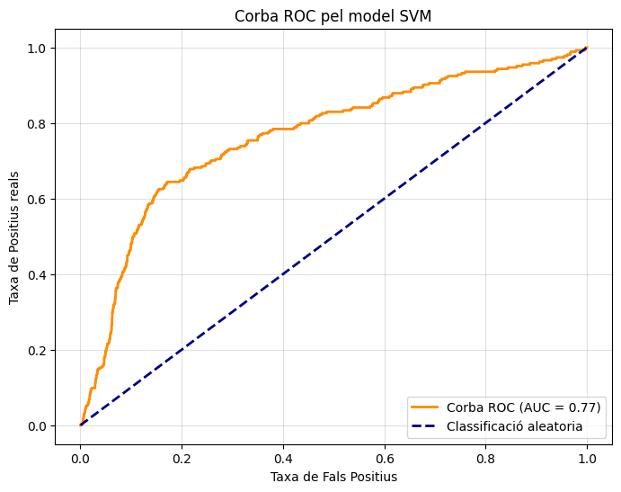

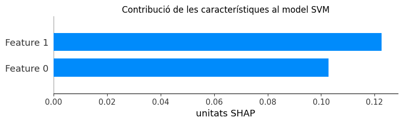

```python
# --------------------
# Model 5: SVM
# --------------------

# Paràmetres SVM ajustats per RandomizedSearch
svm_param_distributions = {
    'C': [0.1, 1, 10],
    'kernel': ['rbf'],
    'gamma': ['scale', 'auto'],
}

svm_random_search = RandomizedSearchCV(
    SVC(probability=True, random_state=42),
    param_distributions=svm_param_distributions,
    n_iter=5,
    cv=2,
    scoring='roc_auc',
    verbose=2,
    n_jobs=1,
    random_state=42
)

svm_random_search.fit(X_train_pca, y_train_resampled)
print(f"\nMillors hiperparàmetres per SVM: {svm_random_search.best_params_}")
print(f"\nMillor puntuació d'entrenament: {svm_random_search.best_score_}")

# Avaluació per SVM
svm_best_model = svm_random_search.best_estimator_
y_pred_svm = svm_best_model.predict(X_test_pca)
print("\nResultats SVM :")
print(classification_report(y_test, y_pred_svm))
print(f"Accuracy: {accuracy_score(y_test, y_pred_svm)}")
print("\nMatriu de Confusió:")
print(confusion_matrix(y_test, y_pred_svm))
y_pred_proba = svm_best_model.predict_proba(X_test_pca)[:, 1]
roc_auc = roc_auc_score(y_test, y_pred_proba)
print(f"\nROC AUC Score: {roc_auc:.4f}")

# --- Visualització Corba ROC ---
fpr, tpr, _ = roc_curve(y_test, y_pred_proba)
roc_auc = auc(fpr, tpr)

plt.figure(figsize=(8, 6))
plt.plot(fpr, tpr, color='darkorange', lw=2, label=f"Corba ROC (AUC = {roc_auc:.2f})")
plt.plot([0, 1], [0, 1], color='navy', lw=2, linestyle='--', label='Classificació aleatoria')
plt.xlabel("Taxa de Fals Positius")
plt.ylabel("Taxa de Positius reals")
plt.title("Corba ROC pel model SVM")
plt.legend(loc="lower right")
plt.grid(alpha=0.4)
plt.show()

explainer = shap.KernelExplainer(svm_best_model.predict_proba, shap.kmeans(X_train_pca, 10))

# Calculem valors SHAP
shap_values = explainer.shap_values(X_test_pca)
shap.summary_plot(shap_values[1], X_test_pca, show=False, plot_type="bar")
plt.title("Contribució de les característiques al model SVM")
plt.xlabel("unitats SHAP")
plt.show()
```

**Comparativa**